# Recessions and Crime

December 2017

*Source file* ⇒ R_Markdown.Rmd

### Introduction

The goal of this project is to determine if there is any correlation between a recession and crime rates. In other words, is there more crime during a recession? In order to do this, I have quarterly GDP data from the St. Louis FED and annual crime statistics from the FBI.

### Data Sources

[Real Gross Domestic Product from FRED](https://fred.stlouisfed.org/series/GDPC1)  
[Crime in the United States from the FBI](https://ucr.fbi.gov/crime-in-the-u.s/2013/crime-in-the-u.s.-2013/tables/1tabledatadecoverviewpdf/table_1_crime_in_the_united_states_by_volume_and_rate_per_100000_inhabitants_1994-2013.xls)

### The Process

First, I need to load the two data sets into R

```r
#Load the data into R

GDP <- read.csv("GDP.csv")
CRIME <-  read.csv("CRIME.csv")
```

In order to find which quarters were in a recession, I will calculate the percentage change for GDP. Then I can filter out all of the positive values to get only recession entries.

```r
#calculate pecentage change of GDP and only display the values for a negative value to show recession years.

GDP_Recession <- GDP%>%                                    #name the table GDP_Recessions and use the GDP data
      mutate(pChange=(GDPC1-lag(GDPC1))/lag(GDPC1)*100)%>% #creates the percentage change variable
      filter(pChange<0) %>%                                #Only display the negative percentage change values
      na.omit()                                            #omit any entries that say NA

knitr::kable(head(GDP_Recession))                          #create neat table for GDP_Recession
```

| DATE | GDPC1 | pChange |
| --- | --- | --- |
| 4/1/1947 | 1932.281 | -0.1132092 |
| 7/1/1947 | 1930.315 | -0.1017450 |
| 1/1/1949 | 2007.522 | -1.3662165 |
| 4/1/1949 | 2000.788 | -0.3354384 |
| 10/1/1949 | 2004.653 | -0.8970248 |
| 7/1/1953 | 2578.922 | -0.5604105 |

Now I will finalize my GDP data. GDP is reported quarterly, but I need to make it annual so that it will match with the Crime table. To make it annual data, I am averaging the percentage change values for each year.

```r
#Crime data is only yearly. so need to get the GDP_Recession data into yearly. To do this, find the yearly average rate for GDP_Recession. Probably better to tell an actual recession because it'll give a closer estimate of consecutive periods and official recessions.

library(stringi)                                         #Required for stri_extract_last_regex

GDP_Recession2 <- GDP_Recession %>%                      #Extracts the year (last four digits) from the date
  mutate(Year=(stri_extract_last_regex(DATE, "\\d{4}")))

GDP_Final<-
group_by(GDP_Recession2,Year ) %>%                       #Finds the average annual percent change in GDP
  summarize(GDP_Rate= mean(pChange))


knitr::kable(head(GDP_Final))                            #create neat table for GDP_Final
```

| Year | GDP_Rate |
| --- | --- |
| 1947 | -0.1074771 |
| 1949 | -0.8662266 |
| 1953 | -1.0389719 |
| 1954 | -0.4623618 |
| 1956 | -0.2338225 |
| 1957 | -0.6234422 |

Next, I need to take some steps to clean my Crime data-set so that R will be able to use it.

```r
#Need to clean up the Crime dataset

Crime2<-CRIME[-c(1,2,24,25,26,27,28,29,30,31,32,33,34,35,36,37),]  #Delete unnecessary rows from Crime and rename the table

colnames(Crime2)[1] <- "Year"                                      #Renaming the column names because they were wrong
colnames(Crime2)[2] <- "Population"
colnames(Crime2)[3] <- "Violent"
colnames(Crime2)[4] <- "Violent_Rate"
colnames(Crime2)[5] <- "Murder_and_Manslaughter"
colnames(Crime2)[6] <- "Murder_and_Manslaughter_Rate"
colnames(Crime2)[7] <- "Rape"
colnames(Crime2)[8] <- "Rape_Rate"
colnames(Crime2)[9] <- "Robbery"
colnames(Crime2)[10] <- "Robbery_Rate"
colnames(Crime2)[11] <- "Aggravated_Assault"
colnames(Crime2)[12] <- "Aggravated_Assault_Rate"
colnames(Crime2)[13] <- "Property"
colnames(Crime2)[14] <- "Property_Crime"
colnames(Crime2)[15] <- "Burglary"
colnames(Crime2)[16] <- "Burglary_Rate"
colnames(Crime2)[17] <- "Larceny"
colnames(Crime2)[18] <- "Larceny_Rate"
colnames(Crime2)[19] <- "Motor_Vehicle_Theft"
colnames(Crime2)[20] <- "Motor_Vehicle_Theft_Rate"

Crime3<- Crime2[-c(1),]                      #Delete the first row because it had header information instead of data

Crime3$X.19<- NULL                           # Delete the last four columns because they all had NA for data
Crime3$X.20<-NULL
Crime3$X.21 <-NULL
Crime3$X.22<-NULL

Crime3[1] <- lapply(Crime3, as.character)    #convert Year to a character so it can be joinged with GDP Year

CRIME_Final <- Crime3                        #Rename the finished clean table CRIME_Final

knitr::kable(head(CRIME_Final))              #create neat table for CRIME_Final
```

|  | Year | Population | Violent | Violent_Rate | Murder_and_Manslaughter | Murder_and_Manslaughter_Rate | Rape | Rape_Rate | Robbery | Robbery_Rate | Aggravated_Assault | Aggravated_Assault_Rate | Property | Property_Crime | Burglary | Burglary_Rate | Larceny | Larceny_Rate | Motor_Vehicle_Theft | Motor_Vehicle_Theft_Rate |
| --- | --- | --- | --- | --- | --- | --- | --- | --- | --- | --- | --- | --- | --- | --- | --- | --- | --- | --- | --- | --- |
| 4 | 1994 | 260,327,021 | 1,857,670 | 713.6 | 23,326 | 9 | 102,216 | 39.3 | 618,949 | 237.8 | 1,113,179 | 427.6 | 12,131,873 | 4,660.20 | 2,712,774 | 1,042.10 | 7,879,812 | 3,026.90 | 1,539,287 | 591.3 |
| 5 | 1995 | 262,803,276 | 1,798,792 | 684.5 | 21,606 | 8.2 | 97,470 | 37.1 | 580,509 | 220.9 | 1,099,207 | 418.3 | 12,063,935 | 4,590.50 | 2,593,784 | 987 | 7,997,710 | 3,043.20 | 1,472,441 | 560.3 |
| 6 | 1996 | 265,228,572 | 1,688,540 | 636.6 | 19,645 | 7.4 | 96,252 | 36.3 | 535,594 | 201.9 | 1,037,049 | 391 | 11,805,323 | 4,451.00 | 2,506,400 | 945 | 7,904,685 | 2,980.30 | 1,394,238 | 525.7 |
| 7 | 1997 | 267,783,607 | 1,636,096 | 611 | 18,208 | 6.8 | 96,153 | 35.9 | 498,534 | 186.2 | 1,023,201 | 382.1 | 11,558,475 | 4,316.30 | 2,460,526 | 918.8 | 7,743,760 | 2,891.80 | 1,354,189 | 505.7 |
| 8 | 1998 | 270,248,003 | 1,533,887 | 567.6 | 16,974 | 6.3 | 93,144 | 34.5 | 447,186 | 165.5 | 976,583 | 361.4 | 10,951,827 | 4,052.50 | 2,332,735 | 863.2 | 7,376,311 | 2,729.50 | 1,242,781 | 459.9 |
| 9 | 1999 | 272,690,813 | 1,426,044 | 523 | 15,522 | 5.7 | 89,411 | 32.8 | 409,371 | 150.1 | 911,740 | 334.3 | 10,208,334 | 3,743.60 | 2,100,739 | 770.4 | 6,955,520 | 2,550.70 | 1,152,075 | 422.5 |

Now I have two tables that are ready to be joined. I will use the year to match them so that each case is a year with crime statistics and a GDP percentage change value

```r
#Need to Join the two tables so each year has a percentage change and crime statistics

Total <-
  CRIME_Final %>%                     #Join CRIME_Final and GDP_Final by year
  full_join(GDP_Final, by="Year")%>%
  na.omit()

knitr::kable(head(Total))             #create neat table for Total
```

|  | Year | Population | Violent | Violent_Rate | Murder_and_Manslaughter | Murder_and_Manslaughter_Rate | Rape | Rape_Rate | Robbery | Robbery_Rate | Aggravated_Assault | Aggravated_Assault_Rate | Property | Property_Crime | Burglary | Burglary_Rate | Larceny | Larceny_Rate | Motor_Vehicle_Theft | Motor_Vehicle_Theft_Rate | GDP_Rate |
| --- | --- | --- | --- | --- | --- | --- | --- | --- | --- | --- | --- | --- | --- | --- | --- | --- | --- | --- | --- | --- | --- |
| 8 | 2001 | 285,317,559 | 1,439,480 | 504.5 | 16,037 | 5.6 | 90,863 | 31.8 | 423,557 | 148.5 | 909,023 | 318.6 | 10,437,189 | 3,658.10 | 2,116,531 | 741.8 | 7,092,267 | 2,485.70 | 1,228,391 | 430.5 | -0.3003078 |
| 15 | 2008 | 304,059,724 | 1,394,461 | 458.6 | 16,465 | 5.4 | 90,750 | 29.8 | 443,563 | 145.9 | 843,683 | 277.5 | 9,774,152 | 3,214.60 | 2,228,887 | 733 | 6,586,206 | 2,166.10 | 959,059 | 315.4 | -1.0916161 |
| 16 | 2009 | 307,006,550 | 1,325,896 | 431.9 | 15,399 | 5 | 89,241 | 29.1 | 408,742 | 133.1 | 812,514 | 264.7 | 9,337,060 | 3,041.30 | 2,203,313 | 717.7 | 6,338,095 | 2,064.50 | 795,652 | 259.2 | -0.7604467 |
| 18 | 2011 | 311,587,816 | 1,206,005 | 387.1 | 14,661 | 4.7 | 84,175 | 27 | 354,746 | 113.9 | 752,423 | 241.5 | 9,052,743 | 2,905.40 | 2,185,140 | 701.3 | 6,151,095 | 1,974.10 | 716,508 | 230 | -0.3862373 |

The tables are joined and now I can plot all the data to see if there is any correlation.

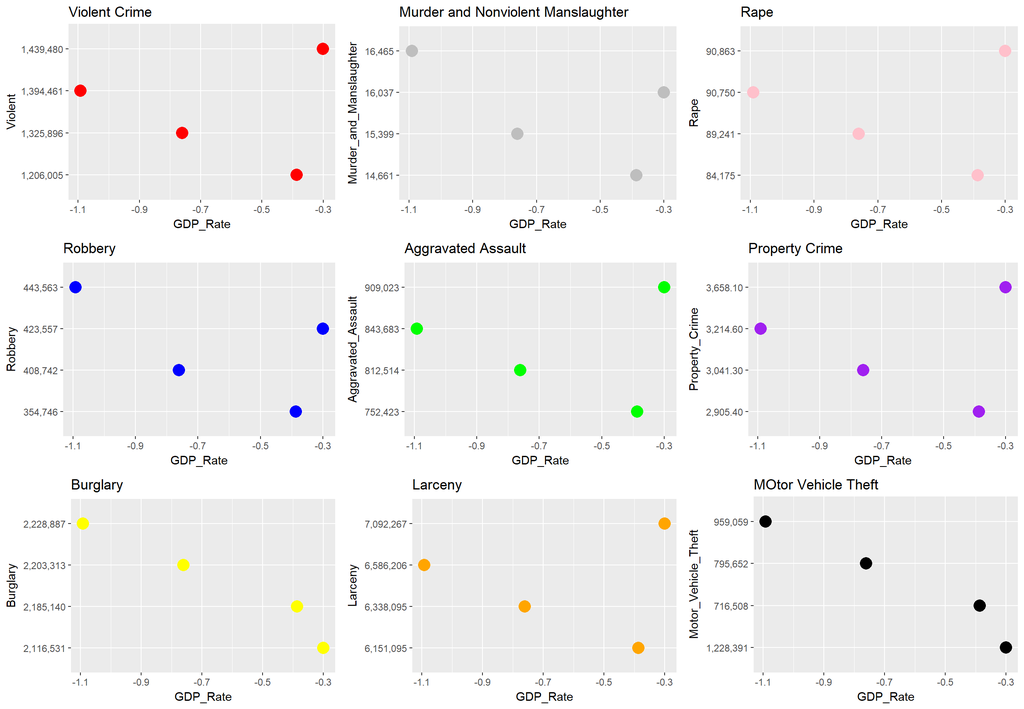

```r
#Time to plot the data! Is there any correlation between recessions and the amount of crime?

a<-ggplot(Total, aes(x=GDP_Rate,y=Violent))+
  geom_point(colour = "red", size = 5)+
  ggtitle("Violent Crime")

b<-ggplot(Total, aes(x=GDP_Rate,y=Murder_and_Manslaughter))+
  geom_point(colour = "gray", size = 5)+
  ggtitle("Murder and Nonviolent Manslaughter")

c<-ggplot(Total, aes(x=GDP_Rate,y=Rape))+
  geom_point(colour = "pink", size = 5)+
  ggtitle("Rape")

d<-ggplot(Total, aes(x=GDP_Rate,y=Robbery))+
  geom_point(colour = "blue", size = 5)+
  ggtitle("Robbery")

e<-ggplot(Total, aes(x=GDP_Rate,y=Aggravated_Assault))+
  geom_point(colour = "green", size = 5)+
  ggtitle("Aggravated Assault")

f<-ggplot(Total, aes(x=GDP_Rate,y=Property_Crime))+
  geom_point(colour = "purple", size = 5)+
  ggtitle("Property Crime")

g<-ggplot(Total, aes(x=GDP_Rate,y=Burglary))+
  geom_point(colour = "yellow", size = 5)+
  ggtitle("Burglary")

h<-ggplot(Total, aes(x=GDP_Rate,y=Larceny))+
  geom_point(colour = "orange", size = 5)+
  ggtitle("Larceny")

i<-ggplot(Total, aes(x=GDP_Rate, y=Motor_Vehicle_Theft))+
  geom_point(colour = "black", size = 5)+
  ggtitle("MOtor Vehicle Theft")

library(ggpubr)                 #Required for ggarrange()

ggarrange(a,b,c,d,e,f,g,h,i)    #Puts all the plots together
```